# HW 1

Dr. Yang Feng

We will be predicting the housing price using the `sahp` dataset in the **r02pro** package. Please answer the following questions.

You can run the following code to prepare the analysis.

```r
library(r02pro)
library(tidyverse)
my_sahp <- sahp %>%
  na.omit() %>%
  dplyr::select(gar_car, liv_area, kit_qual, sale_price)
View(my_sahp)
my_sahp_train <- my_sahp[1:100, ]
my_sahp_test <- my_sahp[-(1:100), ]
```

1. Using the training data `my_sahp_train` to fit a simple linear regression model of `sale_price` on each variable (`gar_car`, `liv_area`, `kit_qual`) separately. For each regression,
   1. Interpret the coefficients and compute the $R^2$. Which variable is most useful in predicting the `sale_price`?
   2. Comput the fitted value and the prediction on the test data, then compute the training and test error. Which variable gives the smallest test error? Does this agree with the variable with the highest $R^2$? Explain your findings.

```r
vars <- c("gar_car", "liv_area", "kit_qual")
R2_seq <- NULL
train_error_seq <- NULL
test_error_seq <- NULL
re <- NULL
beta_coef_seq <- NULL
for(var_ind in seq_along(vars)){
  var <- vars[var_ind]
  fit <- lm(sale_price ~., data = my_sahp_train %>% select(sale_price, all_of(var)))
  print(coef(fit))
  sale_price_pred <- predict(fit, newdata = my_sahp_train)
  train_error_seq[var_ind] <- sum((my_sahp_train$sale_price - sale_price_pred)^2)
  sale_price_pred <- predict(fit, newdata = my_sahp_test)
  test_error_seq[var_ind] <- sum((my_sahp_test$sale_price - sale_price_pred)^2)
  R2_seq[var_ind] <- summary(fit)$r.squared

}
```

```
## (Intercept)     gar_car
##    69.51461    60.90829
## (Intercept)    liv_area
##   8.8985208   0.1132542
##       (Intercept) kit_qualExcellent      kit_qualFair      kit_qualGood
##         137.31516         209.61084         -19.51516          56.61272
```

```r
 lm_re <- data.frame(var = vars,
                  R2 = R2_seq,
                  train_error = train_error_seq,
                  test_error = test_error_seq)
 lm_re
```

| var | R2 | train_error | test_error |
| --- | --- | --- | --- |
| gar_car | 0.3210360 | 409245.0 | 292532.5 |
| liv_area | 0.4733870 | 317415.6 | 259325.2 |
| kit_qual | 0.6067548 | 237028.3 | 300062.5 |

2. Using the training data `my_sahp_train` to fit a linear regression model of `sale_price` on all variables, interpret the coefficients and compute the $R^2$. Then compute the training and test error. Compare the results to Q1 and explain your findings.

```r
fit_all <- lm(sale_price ~., data = my_sahp_train)
summary(fit_all)
```

```
##
## Call:
## lm(formula = sale_price ~ ., data = my_sahp_train)
##
## Residuals:
##     Min      1Q  Median      3Q     Max
## -85.872 -21.532  -0.614  17.439 120.635
##
## Coefficients:
##                     Estimate Std. Error t value Pr(>|t|)
## (Intercept)        23.810321  14.030813   1.697    0.093 .
## gar_car            27.559749   5.830365   4.727 7.98e-06 ***
## liv_area            0.057576   0.009551   6.028 3.23e-08 ***
## kit_qualExcellent 141.628826  15.556563   9.104 1.48e-14 ***
## kit_qualFair      -29.978452  22.164214  -1.353    0.179
## kit_qualGood       21.639955   9.144491   2.366    0.020 *
## ---
## Signif. codes:  0 '***' 0.001 '**' 0.01 '*' 0.05 '.' 0.1 ' ' 1
##
## Residual standard error: 37.32 on 94 degrees of freedom
## Multiple R-squared:  0.7827, Adjusted R-squared:  0.7712
## F-statistic: 67.73 on 5 and 94 DF,  p-value: < 2.2e-16
```

```r
 sale_price_pred <- predict(fit_all, newdata = my_sahp_train)
  train_error_seq <- c(train_error_seq, sum((my_sahp_train$sale_price - sale_price_pred)^2))
  sale_price_pred <- predict(fit_all, newdata = my_sahp_test)
  test_error_seq <- c(test_error_seq, sum((my_sahp_test$sale_price - sale_price_pred)^2))
  R2_seq <- c(R2_seq, summary(fit_all)$r.squared)
  vars <- c(vars, "All")
  lm_re <- data.frame(var = vars,
                         R2 = R2_seq,
                        train_error = train_error_seq,
                        test_error = test_error_seq)
 lm_re
```

| var | R2 | train_error | test_error |
| --- | --- | --- | --- |
| gar_car | 0.3210360 | 409245.0 | 292532.5 |
| liv_area | 0.4733870 | 317415.6 | 259325.2 |
| kit_qual | 0.6067548 | 237028.3 | 300062.5 |
| All | 0.7827407 | 130952.9 | 157186.3 |

3. Now, use the KNN method for predicting the `sale_price` using all predictors.
   1. Vary the nearest number $K$ from 1 to 50 with increment 1. For each $K$, fit the KNN regression model on the training data, and predict on the test data. Visualize the training and test error trend as a function of $K$. Discuss your findings.
   2. Compare the best KNN result with the linear regression result in Q2. Discuss your findings.

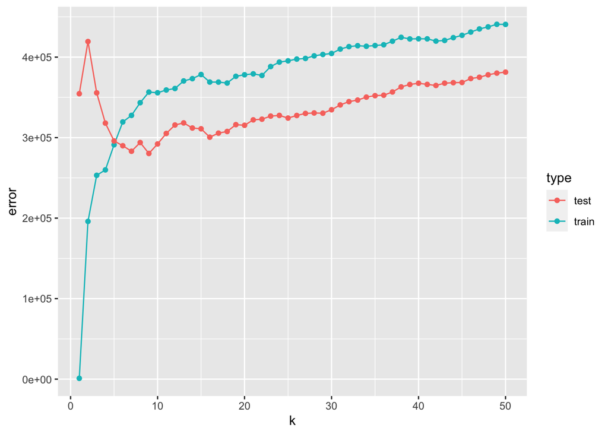

```r
library(caret)
k_seq <- seq(from = 1, to = 50, by = 1)
train_error_seq <- test_error_seq <- NULL
for(k_ind in seq_along(k_seq)){
  k <- k_seq[k_ind]
knn_fit <- knnreg(sale_price ~ .,
                  data = my_sahp_train,
                  k = k)
sale_price_pred <- predict(knn_fit, newdata = my_sahp_train)
  train_error_seq[k_ind] <- sum((my_sahp_train$sale_price - sale_price_pred)^2)
  sale_price_pred <- predict(knn_fit, newdata = my_sahp_test)
  test_error_seq[k_ind] <- sum((my_sahp_test$sale_price - sale_price_pred)^2)

}
re <- rbind(data.frame(k = k_seq, error = train_error_seq, type = "train"),
            data.frame(k = k_seq, error = test_error_seq, type = "test"))

ggplot(re, mapping = aes(x = k, y = error, color = type)) +
  geom_line() +
  geom_point()
```

```r
k_best <- k_seq[which.min(test_error_seq)]
test_error_seq[k_best]
```

```
## [1] 280339.5
```

The optimal choice of $K$ in the KNN is 9 and the corresponding test error is 280339.5, which is larger than 157186.3. This indicates that the linear regression model is better than KNN for this regression problem.

4. ISLR book 2nd Edition Chapter 3.7 Question 6

$$\hat \beta_1 = \frac{\sum^n_{i=1}(x_i - \bar x)(y_i - \bar y)}{\sum^n_{i=1}(x_i - \bar x)^2}$$
$$\hat \beta_0 = \bar y - \hat \beta_1 \bar x$$
where $\bar y = \frac{1}{n}\sum^n_{i=1}y_i$ and $\bar x = \frac{1}{n}\sum^n_{i=1}x_i$

Using (3.4 least squares coeffcient estimates - see equations above), argue that in the case of simple linear regression, theleast squares line always passes through the point $(\bar x, \bar y$).